# HW 03

Author

Matt Osterhoudt

## 0 - Setup

```r
knitr::opts_chunk$set(message = FALSE, warning = FALSE)

if (!require("pacman"))
  install.packages("pacman")

# use this line for installing/loading
 pacman::p_load(tidyverse,
                palmerpenguins,
                here,
                cowgrid,
                dsbox,
                fs,
                janitor,
                scales,
                ggforce,
                glue,
                jpeg,
                png,
                grid,
                cowplot)
install.packages("openintro")
install.packages("ggridges")
library(openintro)
library(ggridges)

devtools::install_github("tidyverse/dsbox")

ggplot2::theme_set(ggplot2::theme_minimal(base_size = 14))

knitr::opts_chunk$set(
  fig.width = 7,
  fig.asp = .618,
  fig.retina = 3,
  fig.align = "center",
  dpi = 300
)
```

## 1 - Du Bois challenge.

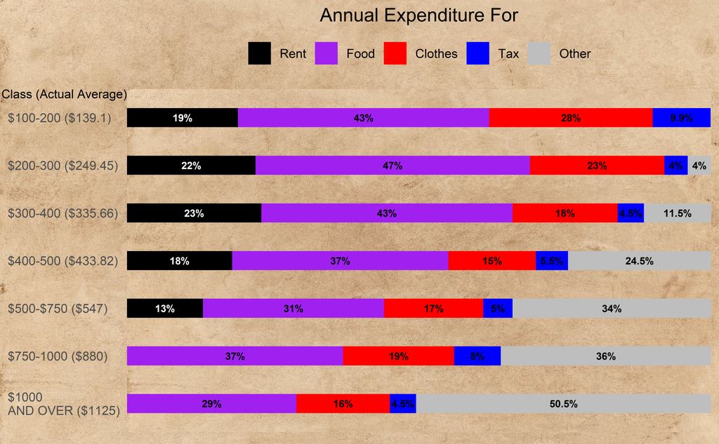

```r
# Reading in the data and pivoting the data to a longer format. This will help with the visualization.
income_data <- read_csv(here("data", "income.csv"))
income_data_longer <- pivot_longer(
  income_data,
  cols = c("Rent", "Food", "Clothes", "Tax", "Other"),
  names_to = "Category",
  values_to = "Percentage"
)

# Modifies the Category order to match
income_data_longer$Category <- factor(income_data_longer$Category,
                                      levels = c("Rent", "Food", "Clothes", "Tax", "Other"))

y_axis_relabel <- c(
  "$100-200" = "$100-200 ($139.1)",
  "$200-300" = "$200-300 ($249.45)",
  "$300-400" = "$300-400 ($335.66)",
  "$400-500" = "$400-500 ($433.82)",
  "$500-750" = "$500-$750 ($547)",
  "$750-1000" = "$750-1000 ($880)",
  "$1000 AND OVER" =  "$1000\nAND OVER ($1125)"
)

# Reads in the background.
background_img <- readJPEG(here("images", "parchment_paper.jpg"))

plot_output <- ggplot(income_data_longer, aes(x = Percentage, y = Class, fill = Category)) +
  annotation_raster(background_img, xmin = -Inf, xmax = Inf, ymin = -Inf, ymax = Inf) +
  geom_bar(stat = "identity", width = 0.4, position = position_stack(reverse = TRUE)) +
  scale_y_discrete(limits = rev(c(
    "$100-200", "$200-300", "$300-400", "$400-500",
    "$500-750", "$750-1000", "$1000 AND OVER"
  )),labels = y_axis_relabel) +
  scale_fill_manual(values = c(
    "Rent" = "black",
    "Food" = "purple",
    "Clothes" = "red",
    "Tax" = "blue",
    "Other" = "gray"
  )) +
  geom_text(
    aes(label = case_when(Percentage < 1 ~ "", TRUE ~ paste0(Percentage, "%"))),
    color =  ifelse(income_data_longer$Category == "Rent", "white", "black"),
    fontface = "bold",
    size = 2.5,
    position = position_stack(vjust = 0.5, reverse = TRUE)
    ) +
  labs(
    y = NULL,
    x = NULL,
    title = "Annual Expenditure For"
  ) +
  theme_minimal() +
  coord_cartesian(clip = "off") +
  scale_x_continuous(limits = c(0, 100), expand = c(0,0)) +
  theme(
    panel.grid.major = element_blank(),
    panel.grid.minor = element_blank(),
    axis.text.y = element_text(hjust = 0),
    axis.title.y = element_text(angle = 0, size = 10, hjust = -2),
    axis.text.x = element_blank(),
    legend.position = "top",
    legend.title = element_blank(),
    legend.direction = "horizontal",
    plot.title = element_text(hjust = 0.5)
  ) +
  annotate("text",
           x = 0,
           y = 7.5,
           label = "Class (Actual Average)",
           hjust = 1,
           size = 3)
# This code creates a new grid with our read in image as the background, and places our plot over it.
grid.newpage()
grid.raster(background_img, width = unit(1, "npc"), height = unit(1, "npc"))
print(plot_output, newpage = FALSE)
```

I used https://www.geeksforgeeks.org/r-language/how-to-add-image-to-ggplot2-in-r/ to help figure out how to add the background image.  
I also briefly utilized AI in order to figure out how to plot the background image on everything, because it initially was only capturing the plot and ignored the axis points and legend. AI suggested using the grid package, so I tried that out.

## 2 - COVID survey - interpret

This plot is a visual of Covid survey responses regarding attitudes toward COVID-19 vaccines. The x-axis shows the Likert scale from 1-5 for each question, 1 being most agreeable and 5 being least agreeable. The y-axis contains all of the different groups categorized by varying demographics (age, gender, profession, etc.). I do agree with some of these results intuitively. For example, I expected that anyone with a background in medicine would view the vaccine in a positive way. As expected, those in the medical profession ranked many of the questions on the Likert scale closer to a 1 or a 2. I was a little surprised to see that, when comparing medical and nursing results on the question “I will recommend the vaccine…”, that there was a bit more variance on the medical profession. I expected the medical profession and nursing profession to be very very close in scoring. I also expected that the younger generation would rate the vaccine as safer and higher confidence, which turned out to be true in the data, especially compared to older ages.

## 3 - COVID survey - reconstruct

```r
raw_data <- read_csv(here("data", "covid-survey.csv"), skip = 1)
view(raw_data)

clean_raw_data <- raw_data |>
  filter(!if_all(-response_id, is.na))

view(clean_raw_data)

relabel_data <- clean_raw_data |>
  mutate(
    exp_already_vax = case_when(exp_already_vax == 0 ~ "No",
                                exp_already_vax == 1 ~ "Yes", TRUE ~ NA_character_),
    exp_flu_vax = case_when(exp_flu_vax == 0 ~ "No",
                            exp_flu_vax == 1 ~ "Yes", TRUE ~ NA_character_),
    exp_profession = case_when(exp_profession == 0 ~ "Medical",
                               exp_profession == 1 ~ "Nursing", TRUE ~ NA_character_),
    exp_gender = case_when(exp_gender == 0 ~ "Male", exp_gender == 1 ~ "Female",
                           exp_gender == 3 ~ "Non-binary third gender", exp_gender == 4 ~ "Prefer not to say",
                           TRUE ~ NA_character_),
    exp_race = case_when(exp_race == 1 ~ "American Indian / Alaskan Native",
                         exp_race == 2 ~ "Asian",
                         exp_race == 3 ~ "Black / African American",
                         exp_race == 4 ~ "Native Hawaiian / Other Pacific Islander",
                         exp_race == 5 ~ "White", TRUE ~ NA_character_),
    exp_ethnicity = case_when(exp_ethnicity == 1 ~ "Hispanic / Latino",
                              exp_ethnicity == 2 ~ "Non-Hispanic / Non-Latino", TRUE ~ NA_character_),
    exp_age_bin = case_when(
        exp_age_bin == 0 ~ "<20",
        exp_age_bin == 20 ~ "21-25",
        exp_age_bin == 25 ~ "26-30",
        exp_age_bin == 30 ~ ">30", TRUE ~ NA_character_),
  )
view(relabel_data)

# The first pivot takes all columns starting with exp_ and groups them into two new columns
# called explanatory and explanatory_value. Each explanatory variable is now its own row entry
# The second pivot now modifies the columns with "resp_" to do something similar. It groups the
# output of the first pivot into multiple rows based on resp.
covid_survey_longer <- relabel_data |>
  pivot_longer(
    cols = starts_with("exp_"),
    names_to = "explanatory",
    values_to = "explanatory_value"
  ) |>
  filter(!is.na(explanatory_value)) |>
  pivot_longer(
    cols = starts_with("resp_"),
    names_to = "response",
    values_to = "response_value"
  )


covid_survey_longer
```

```
# A tibble: 43,428 × 5
   response_id explanatory    explanatory_value response          response_value
         <dbl> <chr>          <chr>             <chr>                      <dbl>
 1           1 exp_profession Nursing           resp_safety                    5
 2           1 exp_profession Nursing           resp_confidence_…              2
 3           1 exp_profession Nursing           resp_concern_saf…              2
 4           1 exp_profession Nursing           resp_feel_safe_a…              1
 5           1 exp_profession Nursing           resp_will_recomm…              1
 6           1 exp_profession Nursing           resp_trust_info                1
 7           1 exp_flu_vax    Yes               resp_safety                    5
 8           1 exp_flu_vax    Yes               resp_confidence_…              2
 9           1 exp_flu_vax    Yes               resp_concern_saf…              2
10           1 exp_flu_vax    Yes               resp_feel_safe_a…              1
# ℹ 43,418 more rows
```

```r
covid_survey_summary_stats_by_group <- covid_survey_longer |>
  group_by(explanatory, explanatory_value, response) |>
  summarize(
    mean = mean(response_value, na.rm = TRUE),
    low = quantile(response_value, probs = 0.1, na.rm = TRUE),
    high = quantile(response_value, probs = 0.9, na.rm = TRUE)
  )
covid_survey_summary_stats_by_group
```

```
# A tibble: 126 × 6
# Groups:   explanatory, explanatory_value [21]
   explanatory explanatory_value response                 mean   low  high
   <chr>       <chr>             <chr>                   <dbl> <dbl> <dbl>
 1 exp_age_bin 21-25             resp_concern_safety      3.32     2     5
 2 exp_age_bin 21-25             resp_confidence_science  1.31     1     2
 3 exp_age_bin 21-25             resp_feel_safe_at_work   1.20     1     2
 4 exp_age_bin 21-25             resp_safety              1.95     1     5
 5 exp_age_bin 21-25             resp_trust_info          1.29     1     2
 6 exp_age_bin 21-25             resp_will_recommend      1.09     1     1
 7 exp_age_bin 26-30             resp_concern_safety      3.35     1     5
 8 exp_age_bin 26-30             resp_confidence_science  1.40     1     2
 9 exp_age_bin 26-30             resp_feel_safe_at_work   1.29     1     2
10 exp_age_bin 26-30             resp_safety              2.16     1     5
# ℹ 116 more rows
```

```r
covid_survey_summary_stats_all <- covid_survey_longer |>
  group_by(response) |>
  summarize(
    mean = mean(response_value, na.rm = TRUE),
    low = quantile(response_value, probs = 0.1, na.rm = TRUE),
    high = quantile(response_value, probs = 0.9, na.rm = TRUE)
  ) |>
  ungroup() |>
  mutate(
    explanatory = "All",
    explanatory_value = ""
  )

covid_survey_summary_stats_all
```

```
# A tibble: 6 × 6
  response                 mean   low  high explanatory explanatory_value
  <chr>                   <dbl> <dbl> <dbl> <chr>       <chr>
1 resp_concern_safety      3.28     1     5 All         ""
2 resp_confidence_science  1.43     1     2 All         ""
3 resp_feel_safe_at_work   1.36     1     2 All         ""
4 resp_safety              2.03     1     5 All         ""
5 resp_trust_info          1.40     1     2 All         ""
6 resp_will_recommend      1.21     1     2 All         ""
```

```r
covid_survey_summary_stats <- bind_rows(
  covid_survey_summary_stats_by_group, covid_survey_summary_stats_all
)

covid_survey_summary_stats
```

```
# A tibble: 132 × 6
# Groups:   explanatory, explanatory_value [22]
   explanatory explanatory_value response                 mean   low  high
   <chr>       <chr>             <chr>                   <dbl> <dbl> <dbl>
 1 exp_age_bin 21-25             resp_concern_safety      3.32     2     5
 2 exp_age_bin 21-25             resp_confidence_science  1.31     1     2
 3 exp_age_bin 21-25             resp_feel_safe_at_work   1.20     1     2
 4 exp_age_bin 21-25             resp_safety              1.95     1     5
 5 exp_age_bin 21-25             resp_trust_info          1.29     1     2
 6 exp_age_bin 21-25             resp_will_recommend      1.09     1     1
 7 exp_age_bin 26-30             resp_concern_safety      3.35     1     5
 8 exp_age_bin 26-30             resp_confidence_science  1.40     1     2
 9 exp_age_bin 26-30             resp_feel_safe_at_work   1.29     1     2
10 exp_age_bin 26-30             resp_safety              2.16     1     5
# ℹ 122 more rows
```

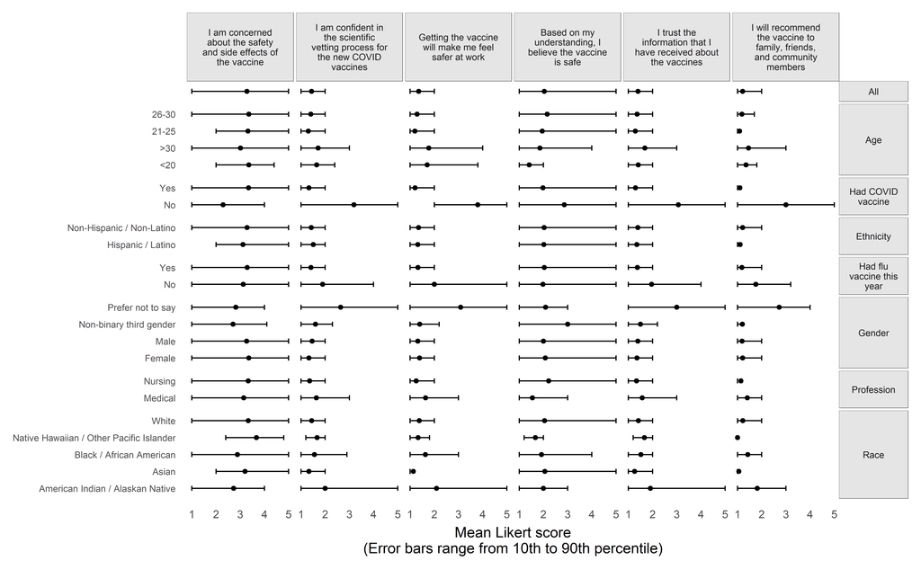

```r
response_labels <- c(
  "resp_safety" = "Based on my understanding,\nI believe the vaccine is safe",
  "resp_confidence_science" = "I am confident in the scientific\nvetting process for the new COVID vaccines",
  "resp_feel_safe_at_work" = "Getting the vaccine will\nmake me feel safer at work",
  "resp_will_recommend" = "I will recommend the vaccine\nto family, friends, and community members",
  "resp_trust_info" = "I trust the information\nthat I have received about the vaccines",
  "resp_concern_safety" = "I am concerned about the safety\nand side effects of the vaccine"
)

explanatory_labels <- c(
  "All"            = "All",
  "exp_age_bin"    = "Age",
  "exp_gender"     = "Gender",
  "exp_race"       = "Race",
  "exp_ethnicity"  = "Ethnicity",
  "exp_profession" = "Profession",
  "exp_already_vax"= "Had COVID vaccine",
  "exp_flu_vax"    = "Had flu vaccine this year"
)


# Plot code below

ggplot(covid_survey_summary_stats, aes(x = mean, y = explanatory_value)) +
  geom_point(size = 0.7) +
  geom_errorbarh(
    aes(xmin = low, xmax = high),
    height = 0.3,
    size = 0.3
  ) +
  facet_grid(explanatory ~ response,
             scales = "free_y",
             space = "free_y",
             labeller = labeller(
               explanatory = as_labeller(explanatory_labels, label_wrap_gen(15)),
               response = as_labeller(response_labels, label_wrap_gen(20))
             )) +
  labs(
    x = "Mean Likert score\n(Error bars range from 10th to 90th percentile)",
    y = NULL
  ) +
  theme(
    strip.background = element_rect(fill = "gray90", color = "black", size = 0.1),
    axis.text.y = element_text(size = 5),
    strip.text.y = element_text(size = 5, angle = 0),
    strip.text.x = element_text(size = 5),
    panel.spacing = unit(.1, "lines"),
    panel.grid.major = element_blank(),
    panel.grid.minor = element_blank(),
    axis.title.x = element_text(size = 8),
    axis.text.x = element_text(size = 6)
  )
```

## 4 - COVID survey - re-reconstruct

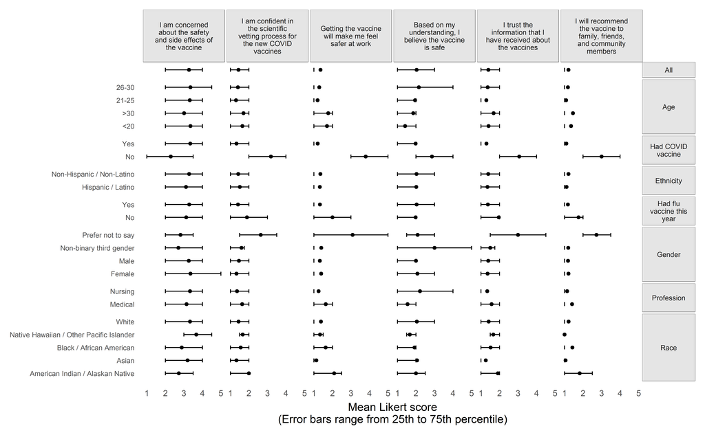

```r
covid_survey_summary_stats_by_group <- covid_survey_longer |>
  group_by(explanatory, explanatory_value, response) |>
  summarize(
    mean = mean(response_value, na.rm = TRUE),
    low = quantile(response_value, probs = 0.25, na.rm = TRUE),
    high = quantile(response_value, probs = 0.75, na.rm = TRUE)
  )

covid_survey_summary_stats_all <- covid_survey_longer |>
  group_by(response) |>
  summarize(
    mean = mean(response_value, na.rm = TRUE),
    low = quantile(response_value, probs = 0.25, na.rm = TRUE),
    high = quantile(response_value, probs = 0.75, na.rm = TRUE)
  ) |>
  ungroup() |>
  mutate(
    explanatory = "All",
    explanatory_value = ""
  )

covid_survey_summary_stats <- bind_rows(
  covid_survey_summary_stats_by_group, covid_survey_summary_stats_all
)

# Plot code below
ggplot(covid_survey_summary_stats, aes(x = mean, y = explanatory_value)) +
  geom_point(size = 0.7) +
  geom_errorbarh(
    aes(xmin = low, xmax = high),
    height = 0.3,
    size = 0.3
  ) +
  facet_grid(explanatory ~ response,
             scales = "free_y",
             space = "free_y",
             labeller = labeller(
               explanatory = as_labeller(explanatory_labels, label_wrap_gen(15)),
               response = as_labeller(response_labels, label_wrap_gen(20))
             )) +
  labs(
    x = "Mean Likert score\n(Error bars range from 25th to 75th percentile)",
    y = NULL
  ) +
  theme(
    strip.background = element_rect(fill = "gray90", color = "black", size = 0.1),
    axis.text.y = element_text(size = 5),
    strip.text.y = element_text(size = 5, angle = 0),
    strip.text.x = element_text(size = 5),
    panel.spacing = unit(.1, "lines"),
    panel.grid.major = element_blank(),
    panel.grid.minor = element_blank(),
    axis.title.x = element_text(size = 8),
    axis.text.x = element_text(size = 6)
  )
```

The plot is now a bit different. Rather than focusing on a wider range of data, the 25th to 75th only focuses on 50% of our data, eliminating some of the variability. The shorter errors bars indicate less variability, but also less information about the ends of our initial distribution. I don’t think this changes my conclusions from before, as the data appears to still trend in a similar way.

## 5 - COVID survey - another view

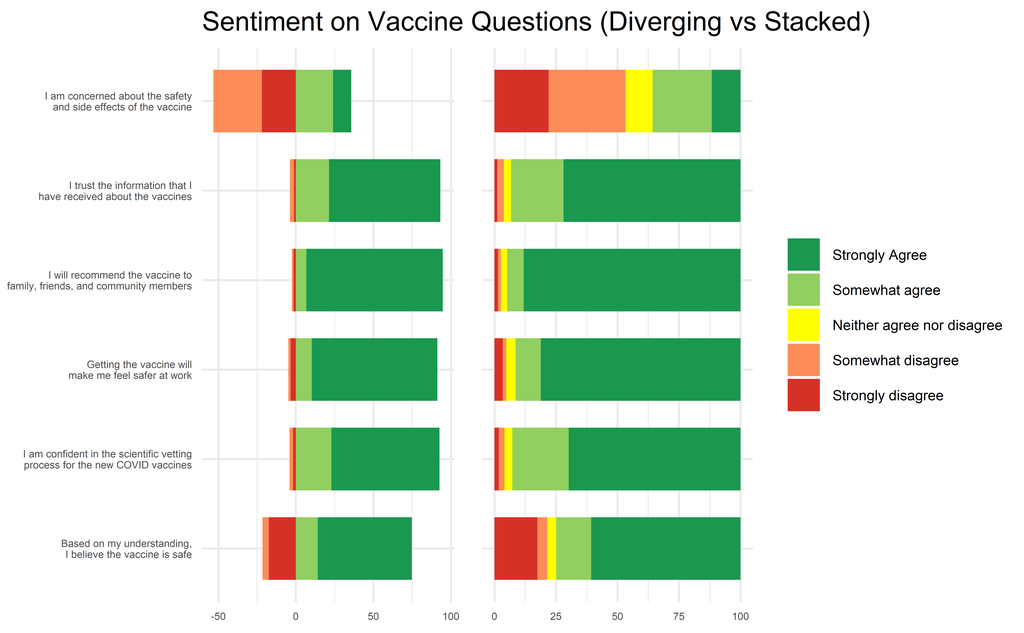

```r
response_labels <- c(
  "resp_safety" = "Based on my understanding,\nI believe the vaccine is safe",
  "resp_confidence_science" = "I am confident in the scientific vetting\nprocess for the new COVID vaccines",
  "resp_feel_safe_at_work" = "Getting the vaccine will\nmake me feel safer at work",
  "resp_will_recommend" = "I will recommend the vaccine to\nfamily, friends, and community members",
  "resp_trust_info" = "I trust the information that I\nhave received about the vaccines",
  "resp_concern_safety" = "I am concerned about the safety\nand side effects of the vaccine"
)

# Grabbing the raw but already filtered data and grabbing the 2 variables needed
percent_data <- covid_survey_longer |>
  filter(!is.na(response_value)) |>
  group_by(response, response_value) |>
  summarize(count = n()) |>
  mutate(percentage = count / sum(count) * 100)

view(percent_data)
percent_data <- percent_data |>
mutate(response_value = case_when(
  response_value == 1 ~ "Strongly Agree",
  response_value == 2 ~ "Somewhat agree",
  response_value == 3 ~ "Neither agree nor disagree",
  response_value == 4 ~ "Somewhat disagree",
  response_value == 5 ~ "Strongly disagree"),
  response = factor(response, levels = names(response_labels), labels = response_labels),
  response_value = factor(response_value, levels = c("Strongly Agree", "Somewhat agree", "Neither agree nor disagree",
                                                    "Somewhat disagree", "Strongly disagree"), ordered = TRUE)
 )
view (percent_data)

diverging_data <- percent_data |>
  mutate(
    pos_or_neg = case_when(
      response_value %in% c("Strongly Agree", "Somewhat agree") ~ percentage,
      response_value %in% c("Strongly disagree", "Somewhat disagree") ~ -percentage,
      response_value == "Neither agree nor disagree" ~ 0 # Or neutral
    )
  )

diverging_bar_chart <- ggplot(diverging_data, aes(x = pos_or_neg, y = response, fill = response_value)) +
  geom_bar(stat = "identity", position = "stack", width = 0.7) +
  scale_fill_manual(
    values = c(
      "Strongly disagree" = "#D73027",
      "Somewhat disagree" = "#FC8D59",
      "Neither agree nor disagree" = "yellow",
      "Somewhat agree" = "#91CF60",
      "Strongly Agree" = "#1A9850"
    )) +
  theme_minimal() +
  theme(
    axis.text = element_text(size = 5),
    legend.title = element_blank()
  ) +
  labs(
    title = "Sentiment on Vaccine Questions (Diverging vs Stacked)",
    x = NULL,
    y = NULL,
    fill = "Response"
  )

bar_chart <- ggplot(percent_data, aes(x = percentage, y = response, fill = response_value)) +
  geom_bar(stat = "identity", position = "stack", width = 0.7) +
  scale_fill_manual(
    values = c(
      "Strongly disagree" = "#D73027",
      "Somewhat disagree" = "#FC8D59",
      "Neither agree nor disagree" = "yellow",
      "Somewhat agree" = "#91CF60",
      "Strongly Agree" = "#1A9850"
    )) +
  theme_minimal() +
  theme(
    axis.text = element_text(size = 5),
    legend.title = element_blank()
  ) +
  labs(
    x = NULL,
    y = NULL,
    fill = "Response"
  )

combined_plot <- plot_grid(
  diverging_bar_chart + theme(legend.position = "none",),
  bar_chart + theme(legend.position = "right",
                    legend.text = element_text(size = 7),
                    axis.text.y = element_blank(
                    )),
  label_size = 10,
  ncol = 2,
  align = "h",
  rel_widths = c(1, 1.2)
)

final_plot <- plot_grid(combined_plot, ncol = 1, rel_heights = c(0.1, 1))
final_plot
```

Comparability: Both charts paint the data in a slightly different way. The diverging chart shows a lot more positive sentiment because of how the data is skewed far more to the right. This is better at showing the overall opinion (agree vs disagree). The stacked bar chart gives a better breakdown of comparing the responses spread out per question. The evenly stacked bars and the colors make it easier to compare the results. It’s also easier to see the split opinions or results in the 100% bar chart rather than the diverging bar chart. Putting both side by side gives us a better overview of the story.